# M11-2: Introduction to Functional Programming in R

Author

Raymond Marquez

Published

April 27, 2026

# 1 Prompt 1.

```r
quantity <- 50

if (quantity > 20) {
  print("You sold a lot")
} else {
  print("Not enough for today.")
}
```

```
[1] "You sold a lot"
```

# 2 Prompt 2.

```r
library(tidyverse)

sales <- 25
case_when(
  sales < 20 ~ "Not enough for today.",
  sales <= 30 ~ "Average Day",
  TRUE ~ "You had a great day!"
) %>%
  print()
```

```
[1] "Average Day"
```

# 3 Prompt 3.

```r
library(glue)
library(tidyverse)

category <- "A"
price <- 100

tax <- c(A=0.08,B=0.10,C=0.20)[category]

final <- price * (1 + tax)

glue("A tax rate of {tax*100}% is applied. The total price is {final}.") %>%
  print()
```

```
A tax rate of 8% is applied. The total price is 108.
```

# 4 Prompt 4.

```r
q4 <- c(2, 5, 3, 9, 8, 11, 6)

count <- 0

for (i in q4) {
  if (i %% 2 == 0) {
    count <- count + 1
  }
}

print(count)
```

```
[1] 3
```

# 5 Prompt 5.

```r
q5 <- 1:8
for(i in q5){
  if(i>4 & i%%2==0){
    print(i)
  } else {
    print("Condition not satisfied")
  }
}
```

```
[1] "Condition not satisfied"
[1] "Condition not satisfied"
[1] "Condition not satisfied"
[1] "Condition not satisfied"
[1] "Condition not satisfied"
[1] 6
[1] "Condition not satisfied"
[1] 8
```

# 6 Prompt 6.

```r
pow <- function(x, y) {
  result <- x^y
  print(paste0(x, " raised to the power of ", y, " is ", result, "."))
}

pow(8, 2)
```

```
[1] "8 raised to the power of 2 is 64."
```

# 7 Prompt 7

### 7.0.1 Run this line of code: df <- data.frame(x = 1:4, y = 5:8, z = 10:13). Use the apply function to get the mean and sum of each ROW on this dataframe. Add them to the data frame.

```r
df <- data.frame(x=1:4,y=5:8,z=10:13)
df$mean <- apply(df,1,function(r) mean(r))
df$sum  <- apply(df,1,function(r) sum(r))
df
```

```
  x y  z     mean      sum
1 1 5 10 5.333333 21.33333
2 2 6 11 6.333333 25.33333
3 3 7 12 7.333333 29.33333
4 4 8 13 8.333333 33.33333
```

## 7.1 Create a vector called q8 and assign the values 12, 18, and 6. Next, use the apply family and map family functions to calculate the square root of each element.

```r
library(purrr)

q8 <- c(12, 18, 6)

# apply family
lapply(q8, sqrt)
```

```
[[1]]
[1] 3.464102

[[2]]
[1] 4.242641

[[3]]
[1] 2.44949
```

```r
# map family
map(q8, sqrt)
```

```
[[1]]
[1] 3.464102

[[2]]
[1] 4.242641

[[3]]
[1] 2.44949
```

```r
q9 <- list(A = 1:5, B = 6:20, C = 1)

lapply(q9, length)
```

```
$A
[1] 5

$B
[1] 15

$C
[1] 1
```

```r
map(q9, length)
```

```
$A
[1] 5

$B
[1] 15

$C
[1] 1
```

## 7.3 What is the difference between lapply and sapply functions. Which map functions are similar to them? Consider that you want to calculate the exponentials of three numbers. In this case, which function you should use and why? Type your answer as a comment?

lapply() always produces a list, whereas sapply() tries to simplify the output into a vector or matrix when possible.

In the purrr package, map() behaves like lapply() by returning a list, while functions such as map_dbl() and map_int() are closer to sapply() since they return simplified numeric vectors.

When computing exponentials, it’s preferable to use sapply() or map_dbl() because they give a numeric vector directly instead of a list.

# 8 Prompt 8

## 8.1 First, execute the following codes in the code chunk to read the data into R and set the global theme.

```r
library(tidyverse)

theme_set(theme_bw())

student_ratio <- read_csv("https://raw.githubusercontent.com/rfordatascience/tidytuesday/master/data/2019/2019-05-07/student_teacher_ratio.csv")
```

## 8.2 Explore the data. Especially count the number of “year”, the “indicator”, and “country”, separately.

```r
student_ratio %>% count(year)
```

```
# A tibble: 7 × 2
   year     n
  <dbl> <int>
1  2012   887
2  2013   880
3  2014   913
4  2015   921
5  2016   917
6  2017   635
7  2018    36
```

```r
student_ratio %>% count(indicator)
```

```
# A tibble: 7 × 2
  indicator                                 n
  <chr>                                 <int>
1 Lower Secondary Education               739
2 Post-Secondary Non-Tertiary Education   494
3 Pre-Primary Education                   837
4 Primary Education                      1029
5 Secondary Education                     840
6 Tertiary Education                      550
7 Upper Secondary Education               700
```

```r
student_ratio %>% count(country)
```

```
# A tibble: 232 × 2
   country                  n
   <chr>                <int>
 1 Afghanistan             13
 2 Africa (Northern)       30
 3 Africa (Sub-Saharan)    28
 4 Albania                 36
 5 Algeria                 18
 6 Andorra                 29
 7 Angola                   7
 8 Antigua and Barbuda     13
 9 Arab States             30
10 Argentina                5
# ℹ 222 more rows
```

## 8.3 Next, draw a chart that shows the top and bottom 10 countries in student-teacher ratio for 2012.

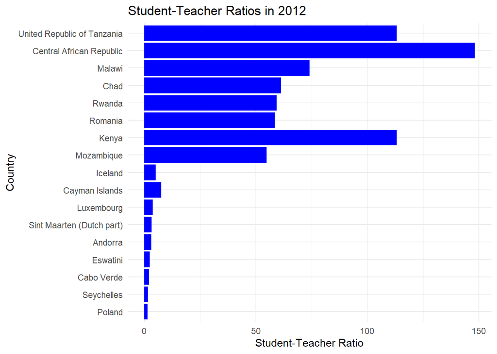

```r
data_2012 <- student_ratio %>%
  filter(year == 2012)

top10 <- data_2012 %>% top_n(10, student_ratio)
bottom10 <- data_2012 %>% top_n(-10, student_ratio)

bind_rows(top10, bottom10) %>%
  ggplot(aes(x = reorder(country, student_ratio), y = student_ratio)) +
  geom_col(fill = "blue") +
  coord_flip() +
  labs(
    title = "Student-Teacher Ratios in 2012",
    x = "Country",
    y = "Student-Teacher Ratio"
  ) +
  theme_minimal()
```

## 8.4 Note that there are six years from 2012 to 2017 that have a significant number of observations, conducive for drawing charts by year. Since you don’t want to copy and paste the code again and again, you want to create a function that allows you to use it to draw all the charts by simply entering “year” information into the function. You will want to show “year” information in the chart as a subtitle. Create such a function.

```r
plot_ratio <- function(year_input){
  student_ratio %>%
    filter(year == year_input) %>%
    top_n(10, student_ratio) %>%
    ggplot(aes(x = reorder(country, student_ratio), y = student_ratio)) +
    geom_col() +
    coord_flip() +
    labs(subtitle = paste("Year:", year_input))
}
```

## 8.5 Draw all charts for 2012 through 2017 using the function.

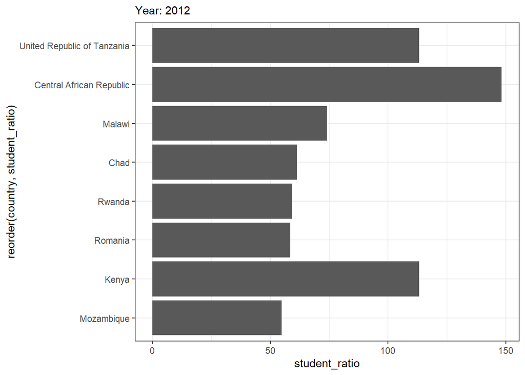

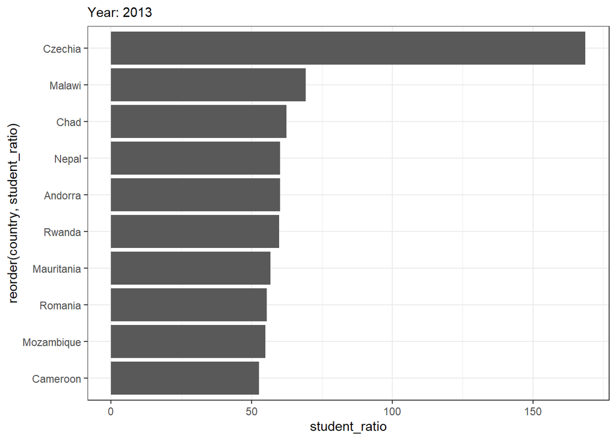

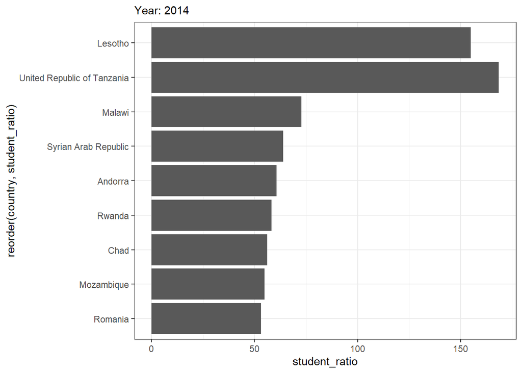

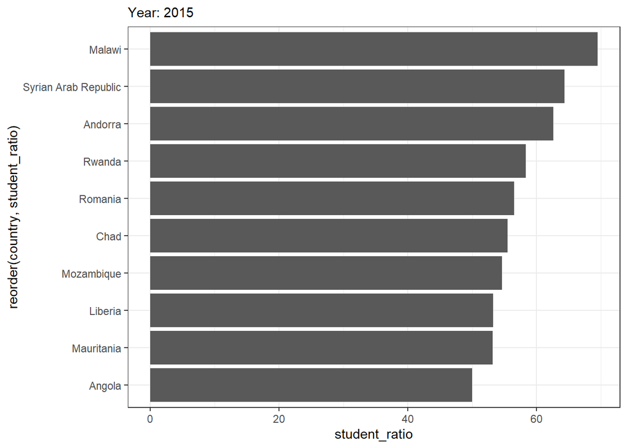

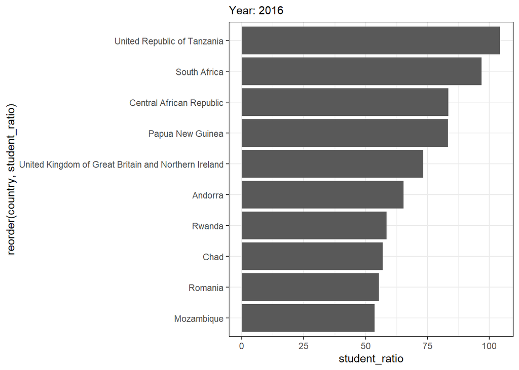

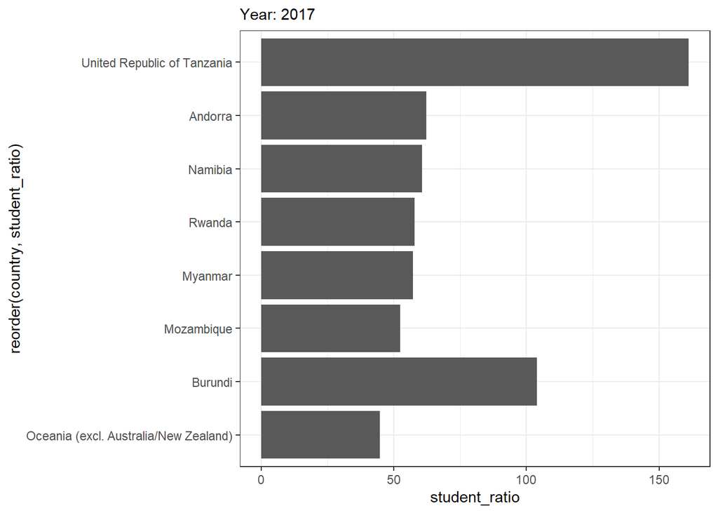

```r
years <- 2012:2017

lapply(years, plot_ratio)
```

# 9 Prompt 9

## 9.1 Read the following data in R and be prepared for analysis

```r
animal_outcomes <- readr::read_csv('https://raw.githubusercontent.com/rfordatascience/tidytuesday/master/data/2020/2020-07-21/animal_outcomes.csv')
animal_complaints <- readr::read_csv('https://raw.githubusercontent.com/rfordatascience/tidytuesday/master/data/2020/2020-07-21/animal_complaints.csv')
brisbane_complaints <- readr::read_csv('https://raw.githubusercontent.com/rfordatascience/tidytuesday/master/data/2020/2020-07-21/brisbane_complaints.csv')
```

## 9.2 First, briefly take a look at each data set. You will notice that some variables are lower case while others are upper case. You will also notice that some variables are consist of more than one word.

```r
glimpse(animal_outcomes)
```

```
Rows: 664
Columns: 12
$ year        <dbl> 1999, 1999, 1999, 1999, 1999, 1999, 1999, 1999, 1999, 1999…
$ animal_type <chr> "Dogs", "Dogs", "Dogs", "Dogs", "Cats", "Cats", "Cats", "C…
$ outcome     <chr> "Reclaimed", "Rehomed", "Other", "Euthanized", "Reclaimed"…
$ ACT         <dbl> 610, 1245, 12, 360, 111, 1442, 0, 1007, 0, 1, 0, 0, 2, 90,…
$ NSW         <dbl> 3140, 7525, 745, 9221, 201, 3913, 447, 8205, 0, 12, 0, 8, …
$ NT          <dbl> 205, 526, 955, 9, 22, 269, 0, 847, 1, 3, 0, 0, 0, 120, 0, …
$ QLD         <dbl> 1392, 5489, 860, 9214, 206, 3901, 386, 10554, 0, 3, 11, 1,…
$ SA          <dbl> 2329, 1105, 380, 1701, 157, 1055, 46, 3415, 2, 10, 1, 0, 1…
$ TAS         <dbl> 516, 480, 168, 599, 31, 752, 124, 1056, 1, 0, 2, 0, 1, 25,…
$ VIC         <dbl> 7130, 4908, 1001, 5217, 884, 3768, 1501, 6113, 87, 19, 0, …
$ WA          <dbl> 1, 137, 6, 18, 0, 62, 5, 5, 0, 0, 0, 0, 0, 3, 0, 0, 0, 0, …
$ Total       <dbl> 15323, 21415, 4127, 26339, 1612, 15162, 2509, 31202, 91, 4…
```

```r
glimpse(animal_complaints)
```

```
Rows: 42,413
Columns: 5
$ `Animal Type`        <chr> "dog", "dog", "dog", "dog", "dog", "dog", "dog", …
$ `Complaint Type`     <chr> "Aggressive Animal", "Noise", "Noise", "Private I…
$ `Date Received`      <chr> "June 2020", "June 2020", "June 2020", "June 2020…
$ Suburb               <chr> "Alice River", "Alice River", "Alice River", "Ali…
$ `Electoral Division` <chr> "Division 1", "Division 1", "Division 1", "Divisi…
```

```r
glimpse(brisbane_complaints)
```

```
Rows: 31,330
Columns: 7
$ nature             <chr> "Animal", "Animal", "Animal", "Animal", "Animal", "…
$ animal_type        <chr> "Dog", "Dog", "Dog", "Dog", "Attack", "Attack", "Do…
$ category           <chr> "Fencing Issues", "Fencing Issues", "Defecating In …
$ suburb             <chr> "SUNNYBANK", "SUNNYBANK HILLS", "SUNNYBANK", "SUNNY…
$ date_range         <chr> "1st-quarter-2016-17.csv", "1st-quarter-2016-17.csv…
$ responsible_office <chr> NA, NA, NA, NA, NA, NA, NA, NA, NA, NA, NA, NA, NA,…
$ city               <chr> "Brisbane", "Brisbane", "Brisbane", "Brisbane", "Br…
```

## 9.3 Create a pipeable function that will help you clean up the variable names across the data set, clean them up using the function, and reassign the data sets to the same names to overwrite them.

```r
library(janitor)

clean_names_fn <- function(df){
  df %>% clean_names()
}

animal_outcomes <- clean_names_fn(animal_outcomes)
animal_complaints <- clean_names_fn(animal_complaints)
brisbane_complaints <- clean_names_fn(brisbane_complaints)
```

## 9.4 Create a pipeable function that can draw a bar chart showing a count of a variable from any of the three data sets above.

```r
plot_bar <- function(df, var){
  df %>%
    count({{var}}) %>%
    ggplot(aes(x = reorder({{var}}, n), y = n)) +
    geom_col(fill = "blue") +
    coord_flip()
}
```

## 9.5 Then, using the function, create two bar charts of your interest from each data set.

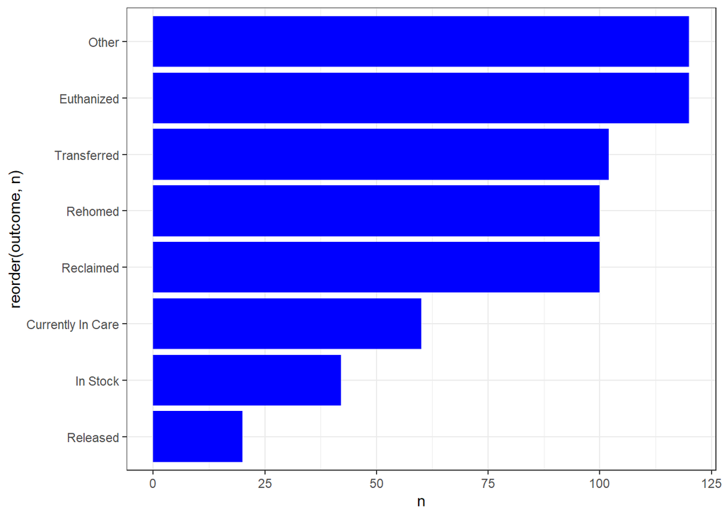

```r
plot_bar(animal_outcomes, outcome)
```

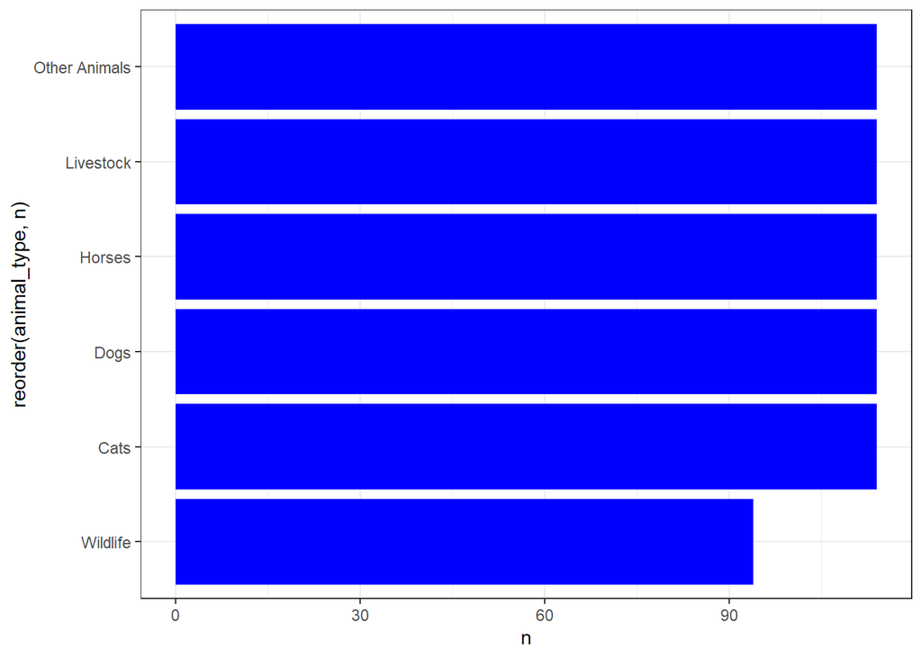

```r
plot_bar(animal_outcomes, animal_type)
```

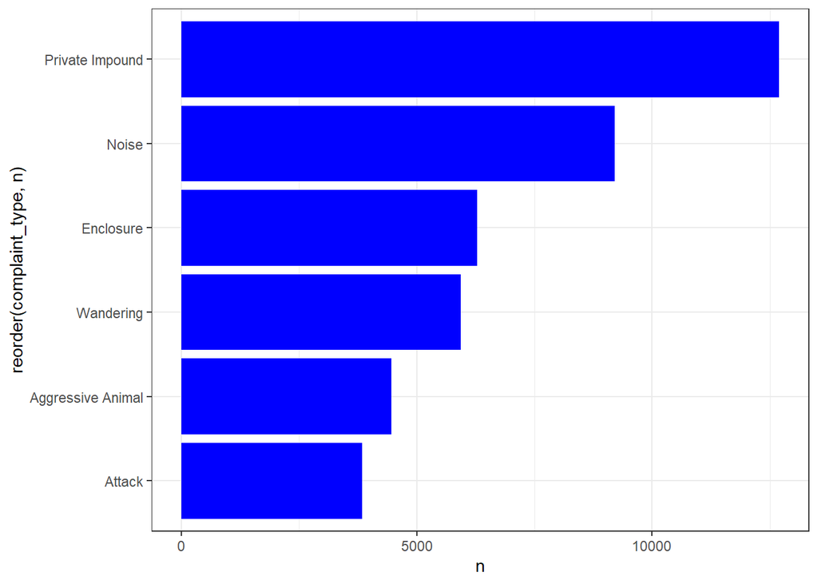

```r
plot_bar(animal_complaints, complaint_type)
```

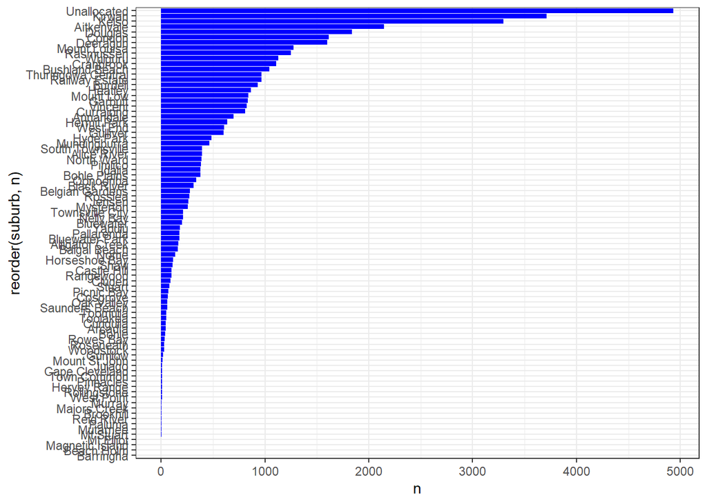

```r
plot_bar(animal_complaints, suburb)
```

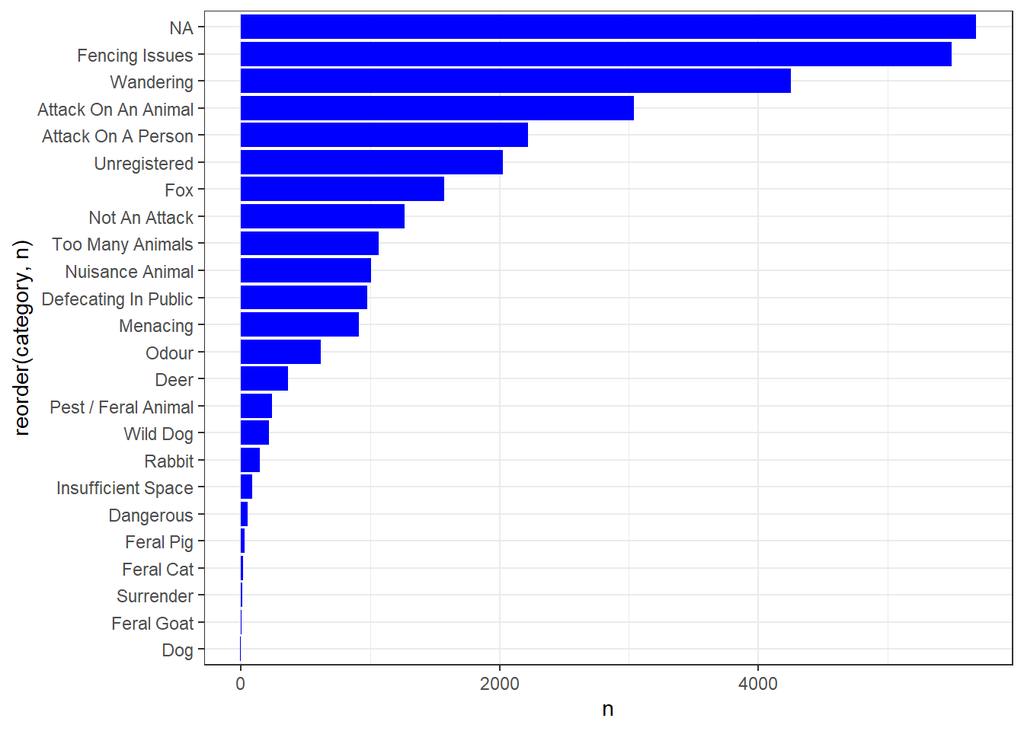

```r
plot_bar(brisbane_complaints, category)
```

[figure not shown]

```r
plot_bar(brisbane_complaints, suburb)
```

# 10 Prompt 10.

```r
# Q10
oz_fun <- function(df){
  df %>% group_by(Month) %>%
    summarise(mean_ozone = mean(Ozone, na.rm=TRUE))
}
oz_fun(airquality)
```

```
# A tibble: 5 × 2
  Month mean_ozone
  <int>      <dbl>
1     5       23.6
2     6       29.4
3     7       59.1
4     8       60.0
5     9       31.4
```